# ITCM: Classification of Handwritten Digits

## Discussion & Future Work

To overcome the disadvantages of the SVD method, may be we could...

1. **Design a preclassification algorithm** to classify some badly drawn images to avoid the misclassification of the SVD,
2. Or figure out a map which maps such too thin, too thick, stretched, jaggy, and crooked images **into a regular images**,
3. Or, instead of using the ture label of the training data directly, we could cluster our training data into several **sublabels**, and then apply the SVD method with this sublabels to the testing data.

### Take a Glampse of the Third Possible Future Work

We used the hierarchical clustering method to cluster the raster vector of each digit over columns. Based on the following visualization, we found that it seems like there may be some sublabels in digits $3$ and $5$, especially, **digit $5$**, which may improve the performance of the SVD method.

### Digit $3$

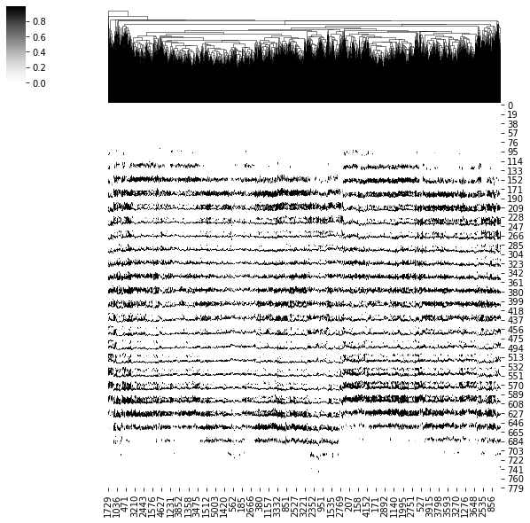

```python
test_f1 = sns.clustermap(x_train3.transpose(), cmap="Greys", row_cluster=False)
```

### Digit $4$

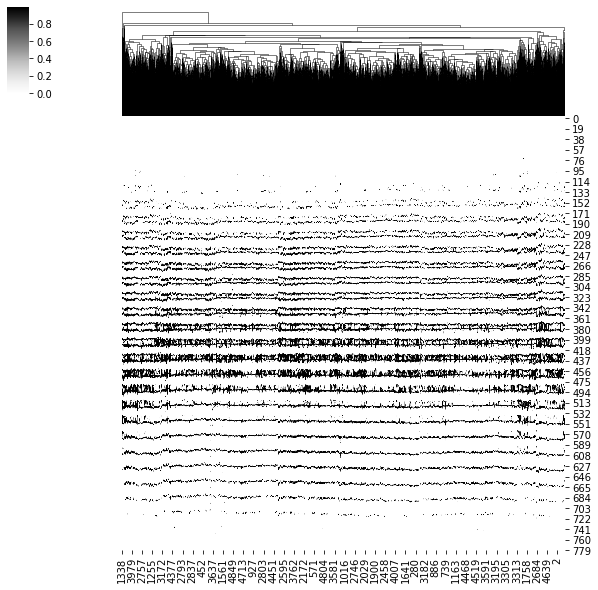

```python
test_f2 = sns.clustermap(x_train4.transpose(), cmap="Greys", row_cluster=False)
```

### Digit $5$

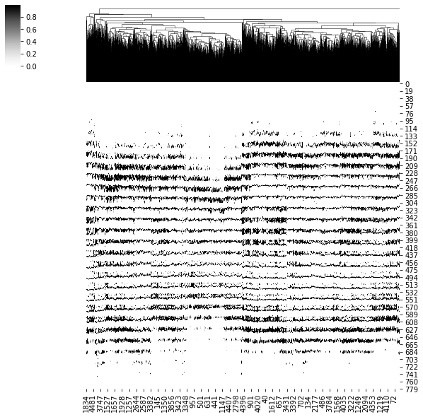

```python
test_f3 = sns.clustermap(x_train5.transpose(), cmap="Greys", row_cluster=False)
```

## The End

Thank you for your attention!

© 2019, Group 31/ Yan-Yu Chen(陳彥宇)/ Econ B05303134.